# Data visualization about US

Adrian Cabrera, Martí Rivero, Gerard Garcia

November 29, 2020

## Importing the dataset

### Explaining the dataset, the data and references

This dataset contains various indicators of health related to diseases, safe living conditions, deaths, births …

The data is organized in states and the 3141 counties of the United States with more than 200 variables in total.

This dataset is not designed only for healthcare professionals but for anyone who wants to do research or improve their community *References*

[Dataset official webpage](https://healthdata.gov/dataset/community-health-status-indicators-chsi-combat-obesity-heart-disease-and-cancer).

## The columns

#### DEMOGRAPHICS COLUMNS

| Name | Data Type | Description |
| --- | --- | --- |
| `State_FIPS_Code` | Text | Two-digit state identifier |
| `County_FIPS_Code` | Text | Three-digit county identifier |
| `CHSI_County_Name` | Text | Name of county |
| `CHSI_State_Name` | Text | Name of State or District of Columbia |
| `Population_Size` | Integer | County data, population size |
| `Poverty` | Decimal | County data, individuals living below poverty level |
| `White` | Decimal | County data, White |
| `Black` | Decimal | County data, Black |
| `Native_American` | Decimal | County data, American Indian |
| `Asian` | Decimal | County data, Asian/Pacific Islander |
| `Hispanic` | Decimal | County data,Hispanic origin |

## Number of rows

```
## [1] 3141
```

## Number of NA

```
## [1] 4
```

#### MEASURESOFBIRTHANDDEATH COLUMNS

| Name | Data Type | Description |
| --- | --- | --- |
| `State_FIPS_Code` | Text | Two-digit state identifier |
| `County_FIPS_Code` | Text | Three-digit county identifier |
| `CHSI_County_Name` | Text | Name of county |
| `CHSI_State_Name` | Text | Name of State or District of Columbia |
| `Infant_Mortality` | Decimal | County data, infant mortality |
| `Lung_Cancer` | Decimal | County data, death measures, lung cancer |
| `Suicide` | Decimal | County data, death measures, suicide |
| `MOBD_Time_Span` | Text | Time period of reported data for measures of birth and death |

## Number of rows

```
## [1] 3141
```

## Number of NA

```
## [1] 41500
```

#### VULNETABLEPOPSANDENVHEALTH COLUMNS

| Name | Data Type | Description |
| --- | --- | --- |
| `State_FIPS_Code` | Text | Two-digit state identifier |
| `County_FIPS_Code` | Text | Three-digit county identifier |
| `CHSI_County_Name` | Text | Name of county |
| `CHSI_State_Name` | Text | Name of State or District of Columbia |
| `Unemployed` | Text | County data, unemployed |

## Number of rows

```
## [1] 3141
```

## Number of NA

```
## [1] 792
```

#### PREVENTIVESERVICESUSE COLUMNS

| Name | Data Type | Description |
| --- | --- | --- |
| `State_FIPS_Code` | Text | Two-digit state identifier |
| `County_FIPS_Code` | Text | Three-digit county identifier |
| `CHSI_County_Name` | Text | Name of county |
| `CHSI_State_Name` | Text | Name of State or District of Columbia |
| `HepA_Rpt` | Integer | County data, Hepatitis A reported cases |
| `HepB_Rpt` | Integer | County data, Hepatitis B reported cases |

## Number of rows

```
## [1] 3141
```

## Number of NA

```
## [1] 32739
```

#### RISKFACTORSANDACCESSTOCARE COLUMNS

| Name | Data Type | Description |
| --- | --- | --- |
| `State_FIPS_Code` | Text | Two-digit state identifier |
| `County_FIPS_Code` | Text | Three-digit county identifier |
| `CHSI_County_Name` | Text | Name of county |
| `CHSI_State_Name` | Text | Name of State or District of Columbia |
| `Obesity` | Decimal | County data,obesity |
| `Smoker` | Decimal | County data,smoker |
| `Uninsured` | Integer | County data,uninsured individuals |

## Number of rows

```
## [1] 3141
```

## Number of NA

```
## [1] 18079
```

### N/A information

In the dataset we have found a report that explains how the NAs are indicated. According to the table we have found multiple values that we converted to NA during import. We indicate these values in the following relationship: (values - additional information)

- -9999 - For unenployed variable.
- -2222, -2222.2, -2 OR nda - No data available
- -1111, -1111.1, -1 OR nrf - No report

## Tidying the dataset

No, the dataset was not cleant. We had to delete colums related to intervals, quantiles, percentiles that we did not require in our case. We used regular expressions patterns, selects and filters to tidy the data as needed.

In some situations we had to convert the data to long format. We invested and found the function pivot_longer() but we could not make use of it since is still in the maturation phrase and it is not included in the tidyverse standard, only in the development version, then we find the function gather with which achieved that change.

## The plots

Used libraries:

`library(tidyverse)`

`library(maps)`

`library(mapproj)`

Tidying data:

#### Exercise 3

Plot which of the most populated states has the gratest infantil mortality.

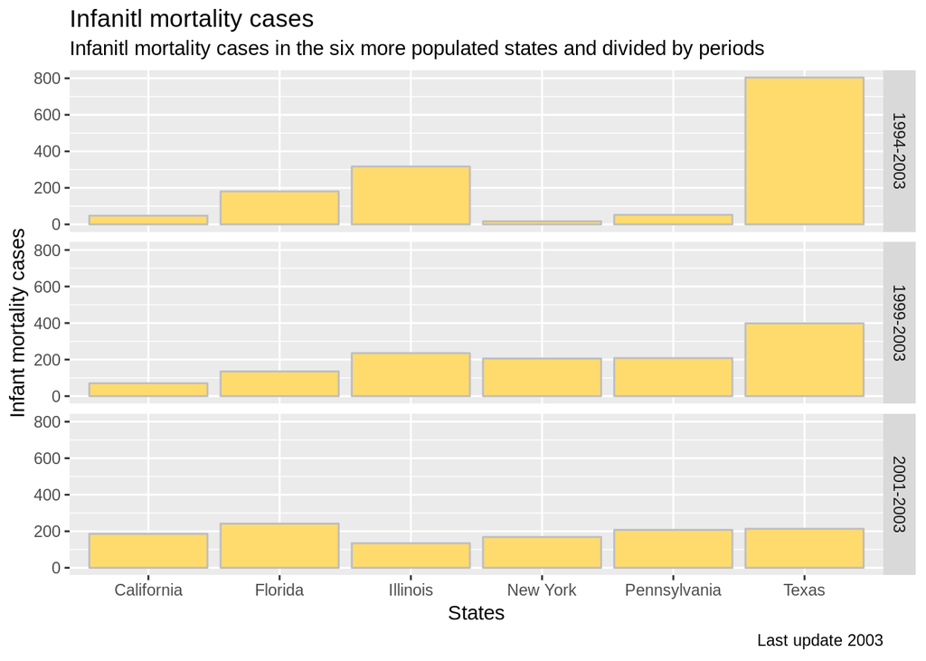

#### Exercise 4

Plot the number of smokers and the lung cancer deaths in the six states with the highest number of smokers.

Result: We cannot arrive at indications of a causation given that for example the state of Elliot County has the lowest percentage of smokers and is the second with the most deaths from lung cancer.

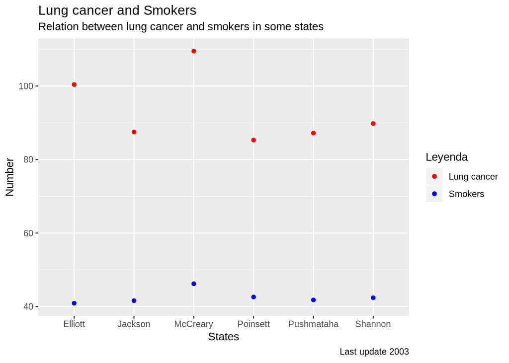

#### Exercise 5

Plot the percentage of races that commit suicide in Bronx.

Result: We observe that the majority races are black and white.

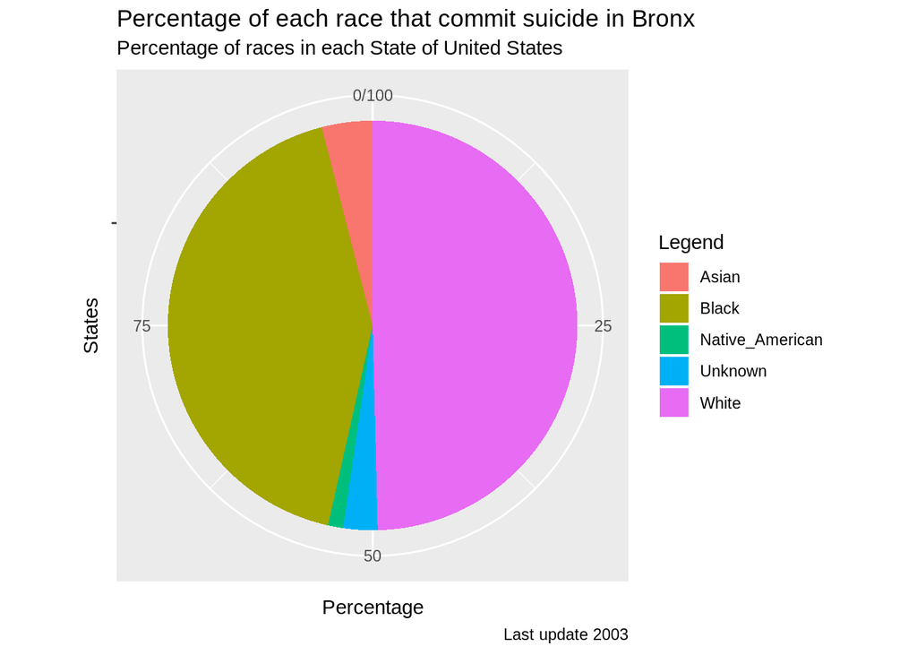

#### Exercise 6

Compare the percentage of each race that are in the east and west coast.

Result: We can see that on the east coast there is a higher percentage of black population than on the west coast.

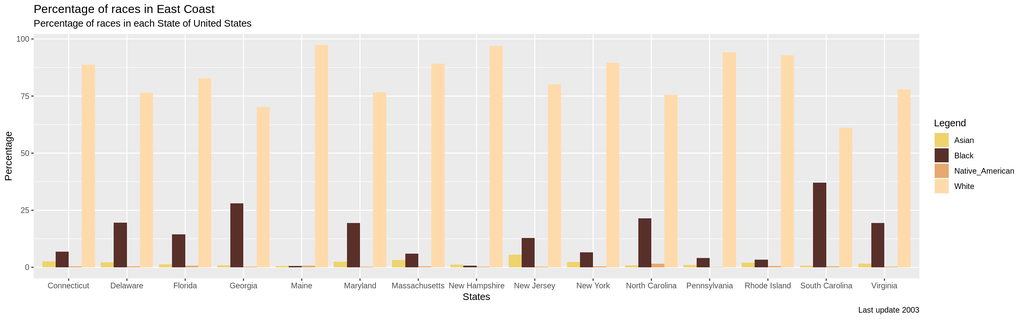

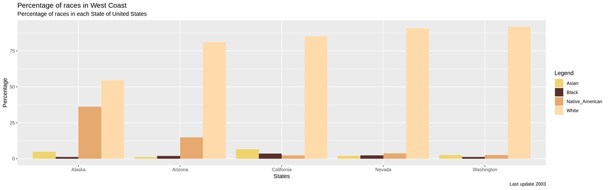

#### Exercise 7

Plot the states with most poverty and compare to its obesity rates.

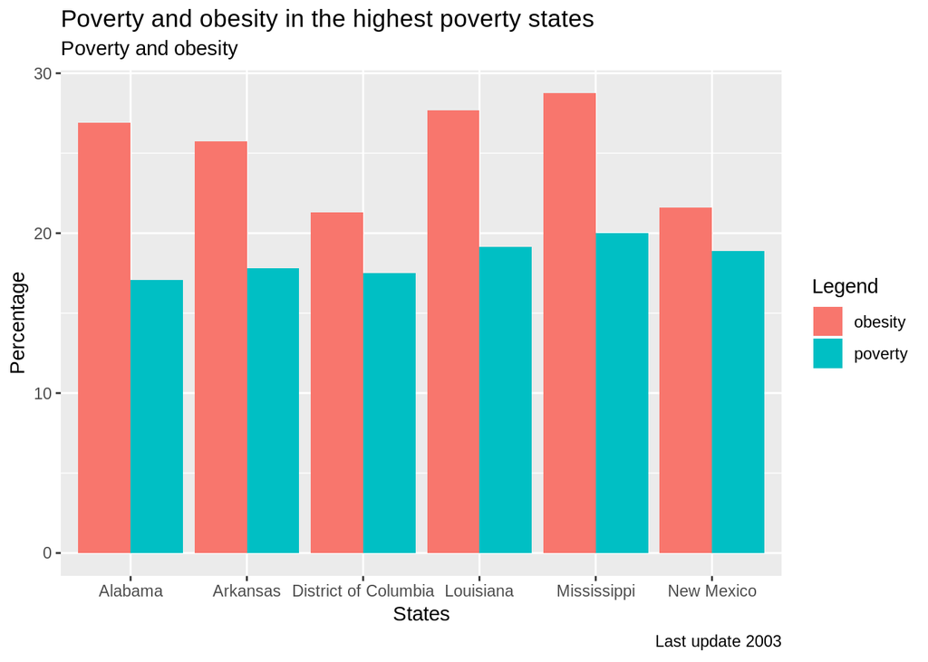

#### Exercise 8

Result: We can see that the southern states are generally poorer than the northern ones.

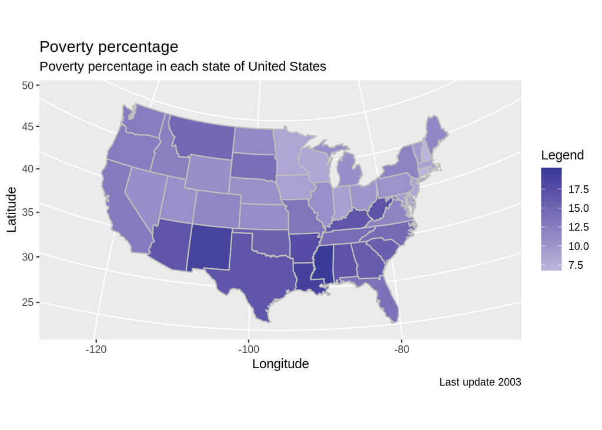

#### Exercise 9

Compare the richest and poorest counties by obesity and unemployment.

Result: We cannot draw any conclusions given the lack of data.

```
## # A tibble: 197,529 x 5
##    CHSI_County_Name Population_Size Obesity Poverty Unemployed
##    <chr>                      <int>   <dbl>   <dbl>      <int>
##  1 Starr                      60941    NA      36.2       2764
##  2 Shannon                    13657    NA      35.6        283
##  3 Shannon                    13657    NA      35.6        457
##  4 Shannon                    13657    29.7    35.6        283
##  5 Shannon                    13657    29.7    35.6        457
##  6 East Carroll                8756    NA      33.9        399
##  7 Todd                        9882    29.2    33.7        369
##  8 Todd                        9882    29.2    33.7        638
##  9 Todd                        9882    29.2    33.7        221
## 10 Todd                        9882    29.7    33.7        369
## # ... with 197,519 more rows
```

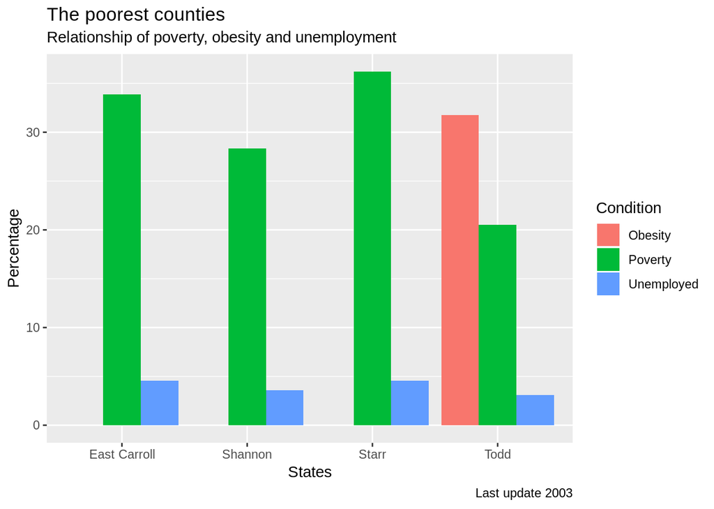

```
## # A tibble: 197,529 x 5
##    CHSI_County_Name Population_Size Obesity Poverty Unemployed
##    <chr>                      <int>   <dbl>   <dbl>      <int>
##  1 Douglas                   249416    11.4     2.2       4893
##  2 Douglas                   249416    11.4     2.2       3181
##  3 Douglas                   249416    11.4     2.2        496
##  4 Douglas                   249416    11.4     2.2       2517
##  5 Douglas                   249416    11.4     2.2        741
##  6 Douglas                   249416    11.4     2.2        362
##  7 Douglas                   249416    11.4     2.2      12041
##  8 Douglas                   249416    11.4     2.2        971
##  9 Douglas                   249416    11.4     2.2       3835
## 10 Douglas                   249416    11.4     2.2         59
## # ... with 197,519 more rows
```

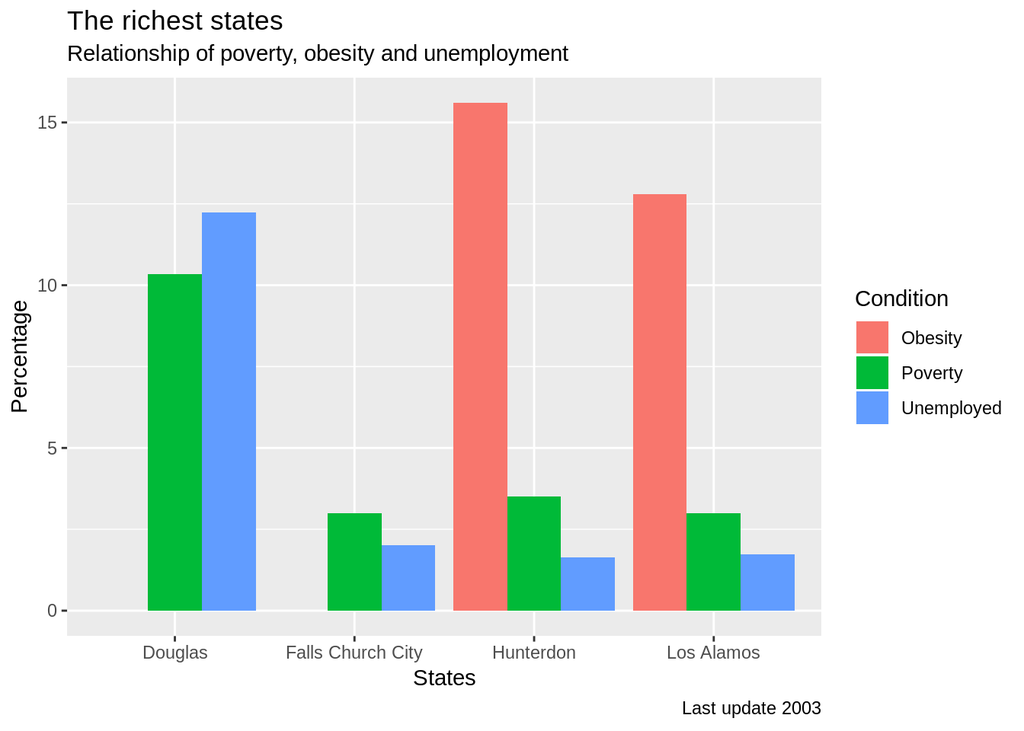

#### Exercice 10

Compare the number of patients with Hepatitis A and B with the level of the population without health insurance.

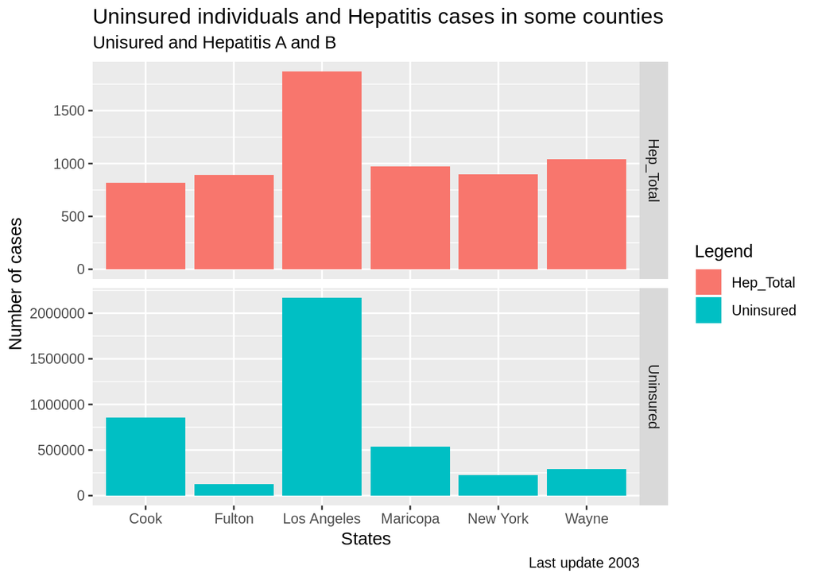